# Take-home Exercise 2: Geospatial Analytics for Peace

Where armed conflict clusters in Myanmar, how its geography is changing, and whether it spreads. 330 townships, January 2021 to September 2025.

## Contents

One question in three parts: where violence clusters, how that is changing, and whether it spreads from one township to the next.

1. The question, the place and the data
2. Clearing the land mines
3. A war that changed its means
4. Where violence clusters
5. Every kind of violence, the same core
6. Which way the trends run
7. Emerging hot spots
8. Violence spreads to neighbours
9. Fronts, not sparks
10. What this means for peace-building, and what it cannot say

## 1. The question, the place and the data

53,907

political-violence events

330

townships, MIMU 9.4

19

quarters

2021-25

Jan 2021 to Sep 2025

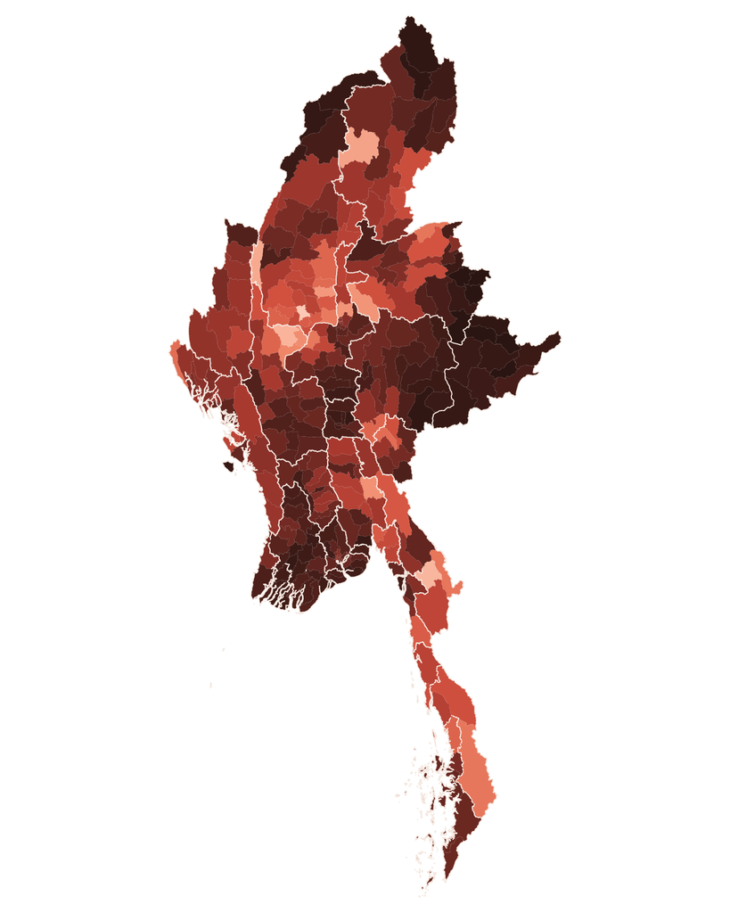

## 2. Clearing the land mines

What I removed

**6 events coded to the Indian Ocean.**

**93 events placed on a regional centroid** (geo_precision 3). Kept, they would pile false violence onto whichever township holds the centroid.

**111 events have no township name**, so I joined every event by its coordinates, not its name. A name join would have lost all of them.

## 3. A war that changed its means

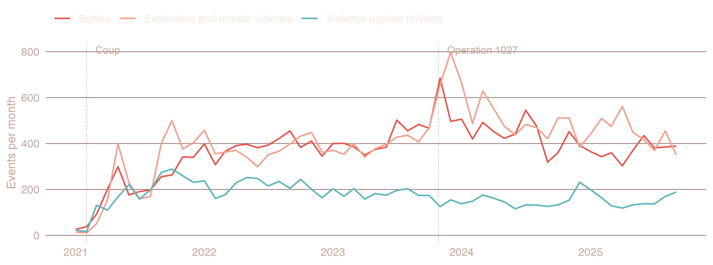

## 4. Where violence clusters

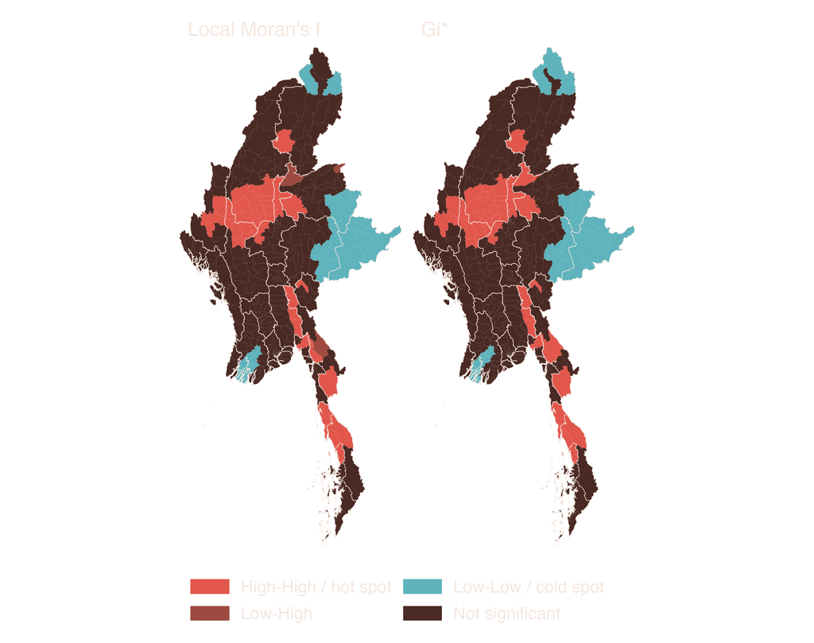

## 5. Every kind of violence, the same core

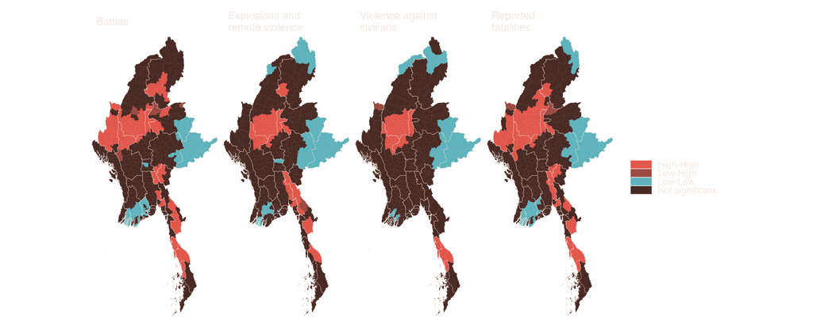

Local Moran’s I by type. **Battles** add the ethnic fronts in Chin, Kachin and Kayah. **Violence against civilians** is the most concentrated: 88% of its High-High townships are in the dry zone. Fatalities follow battles.

## 6. Which way the trends run

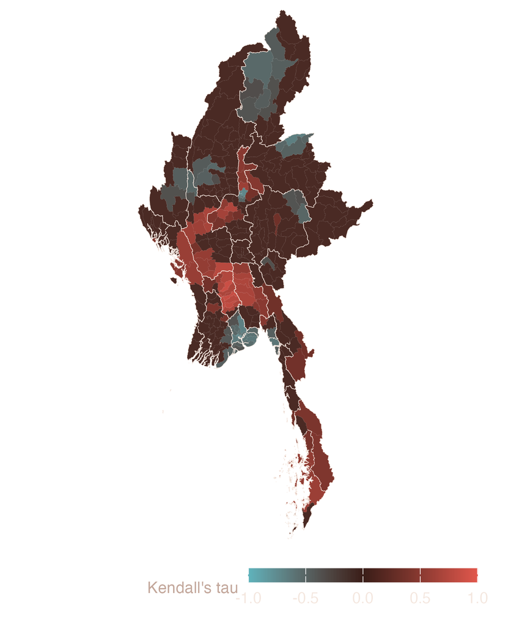

## 7. Emerging hot spots

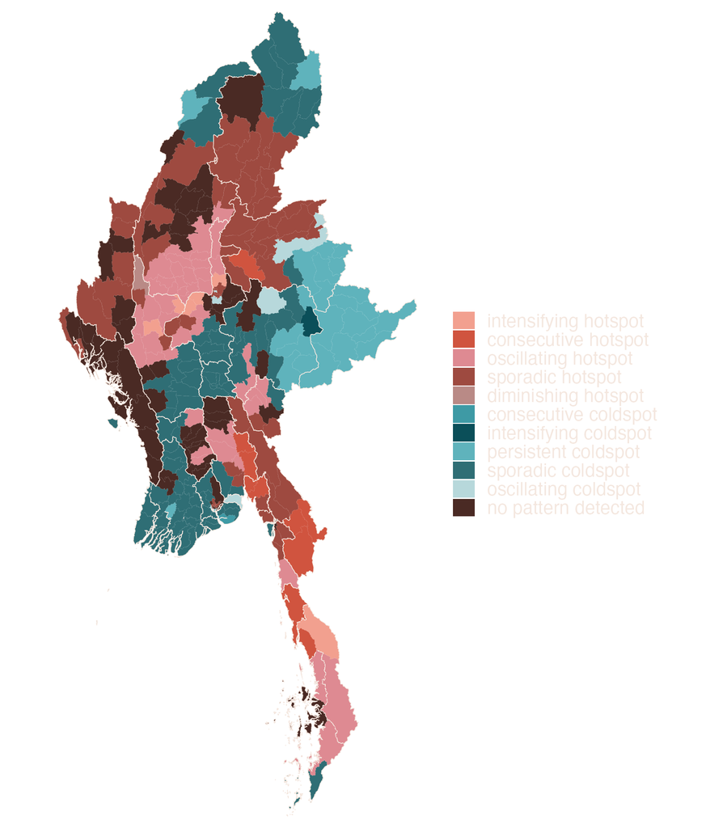

## 8. Violence spreads to neighbours

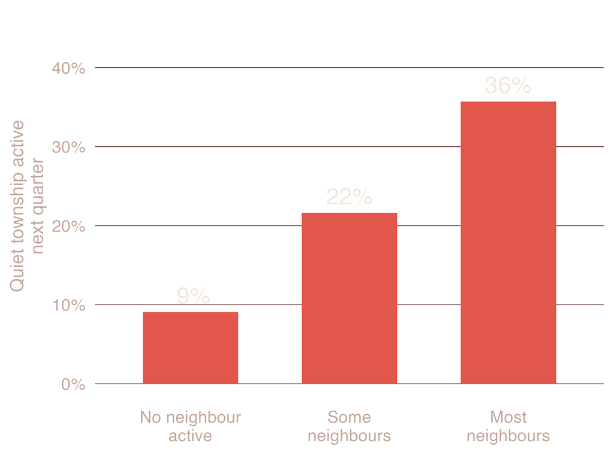

## 9. Fronts, not sparks

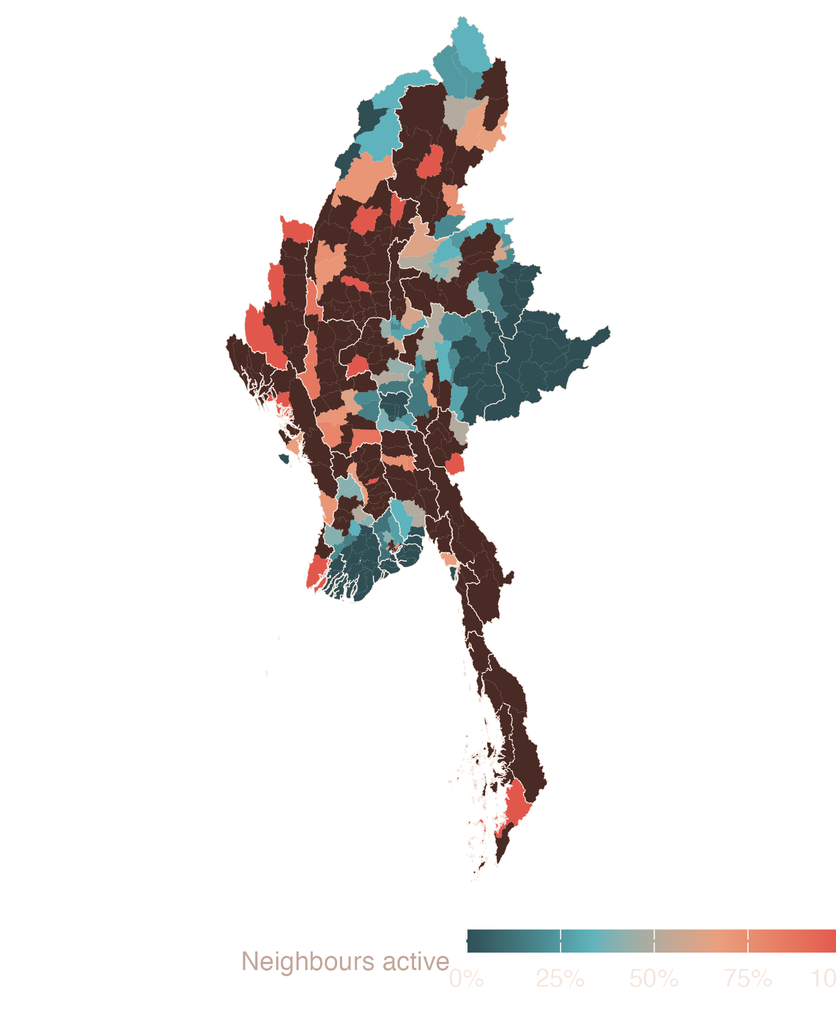

## 10. What this means, and what it cannot say

For peace-building

**Prioritise the intensifying hot spots** (Madaya, Myingyan, Seikphyu, Yesagyo, Ngazun, Dawei) for protection and humanitarian access: established violence that is still rising.

**Watch the quiet edges, not the centres.** Early warning and preparedness belong in quiet townships beside active ones.

**Treat the southeast as a moving front**, where cross-border routes from Thailand matter most.

**Plan for air-strike exposure beyond battle lines.** Battle maps alone will not locate it.